# Chapter 02: Time series graphics

maurogm 2022-12-09

- Link
- `tsibble` objects
- Time plots
- Time series patterns
  - Multiples períodos
  - Seasonal subseries plots
- Scatterplots
- Lag plots
- Autocorrelation

## Link

https://otexts.com/fpp3/graphics.html

## `tsibble` objects

Es un formato que extiende a tibble para trabajar con series de tiempo.

```r
y <- tsibble(
  Year = 2015:2019,
  Observation = c(123, 39, 78, 52, 110),
  index = Year
)
y
```

```
## # A tsibble: 5 x 2 [1Y]
##    Year Observation
##   <int>       <dbl>
## 1  2015         123
## 2  2016          39
## 3  2017          78
## 4  2018          52
## 5  2019         110
```

Imprime cierta información, como el tiempo que transcurre entre cada observación.

```r
olympic_running
```

```
## # A tsibble: 312 x 4 [4Y]
## # Key:       Length, Sex [14]
##     Year Length Sex    Time
##    <int>  <int> <chr> <dbl>
##  1  1896    100 men    12
##  2  1900    100 men    11
##  3  1904    100 men    11
##  4  1908    100 men    10.8
##  5  1912    100 men    10.8
##  6  1916    100 men    NA
##  7  1920    100 men    10.8
##  8  1924    100 men    10.6
##  9  1928    100 men    10.8
## 10  1932    100 men    10.3
## # … with 302 more rows
```

La función `distinct` permite obtener los niveles para los que existen distintas series.

```r
olympic_running %>% distinct(Length)
```

```
## # A tibble: 7 × 1
##   Length
##    <int>
## 1    100
## 2    200
## 3    400
## 4    800
## 5   1500
## 6   5000
## 7  10000
```

```r
olympic_running %>% distinct(Sex, Length)
```

[output not shown]

Ejemplo de conversión de un CSV a tsibble:

```r
prison_csv <- readr::read_csv("https://OTexts.com/fpp3/extrafiles/prison_population.csv")

prison <- prison_csv %>%
  mutate(Quarter = yearquarter(Date)) %>%
  select(-Date) %>%
  as_tsibble(
    key = c(State, Gender, Legal, Indigenous),
    index = Quarter
  )

prison
```

```
## # A tsibble: 3,072 x 6 [1Q]
## # Key:       State, Gender, Legal, Indigenous [64]
##    State Gender Legal    Indigenous Count Quarter
##    <chr> <chr>  <chr>    <chr>      <dbl>   <qtr>
##  1 ACT   Female Remanded ATSI           0 2005 Q1
##  2 ACT   Female Remanded ATSI           1 2005 Q2
##  3 ACT   Female Remanded ATSI           0 2005 Q3
##  4 ACT   Female Remanded ATSI           0 2005 Q4
##  5 ACT   Female Remanded ATSI           1 2006 Q1
##  6 ACT   Female Remanded ATSI           1 2006 Q2
##  7 ACT   Female Remanded ATSI           1 2006 Q3
##  8 ACT   Female Remanded ATSI           0 2006 Q4
##  9 ACT   Female Remanded ATSI           0 2007 Q1
## 10 ACT   Female Remanded ATSI           1 2007 Q2
## # … with 3,062 more rows
```

## Time plots

```r
melsyd_economy <- ansett %>%
  filter(Airports == "MEL-SYD", Class == "Economy") %>%
  mutate(Passengers = Passengers / 1000)
```

La función `autoplot` toma el input y genera el gráfico que le parece que tiene más sentido:

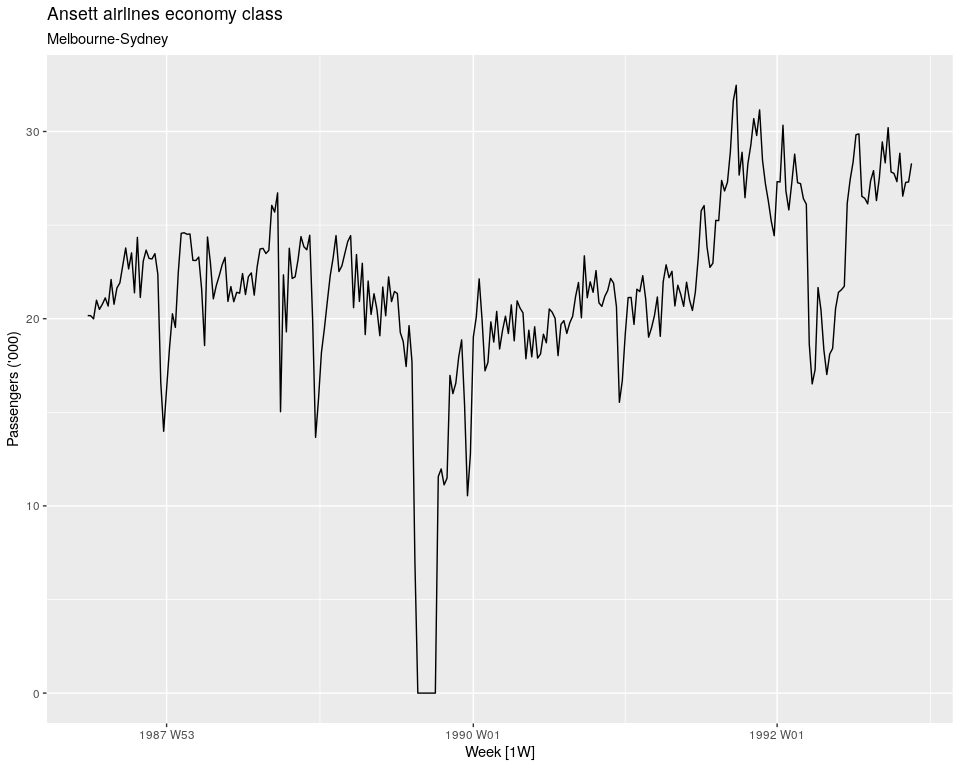

```r
autoplot(melsyd_economy, Passengers) +
  labs(
    title = "Ansett airlines economy class",
    subtitle = "Melbourne-Sydney",
    y = "Passengers ('000)"
  )
```

## Time series patterns

**Trend**: A trend exists when there is a long-term increase or decrease in the data. It does not have to be linear. Sometimes we will refer to a trend as “changing direction”, when it might go from an increasing trend to a decreasing trend.

**Seasonal**: A seasonal pattern occurs when a time series is affected by seasonal factors such as the time of the year or the day of the week. Seasonality is always of a fixed and known period.

**Cyclic**: A cycle occurs when the data exhibit rises and falls that are not of a fixed frequency. These fluctuations are usually due to economic conditions, and are often related to the “business cycle”. The duration of these fluctuations is usually at least 2 years.

## Seasonal plots

```r
a10 <- PBS %>%
  filter(ATC2 == "A10") %>%
  select(Month, Concession, Type, Cost) %>%
  summarise(TotalC = sum(Cost)) %>%
  mutate(Cost = TotalC / 1e6)
```

Imaginemos que tengo el siguiente autoplot:

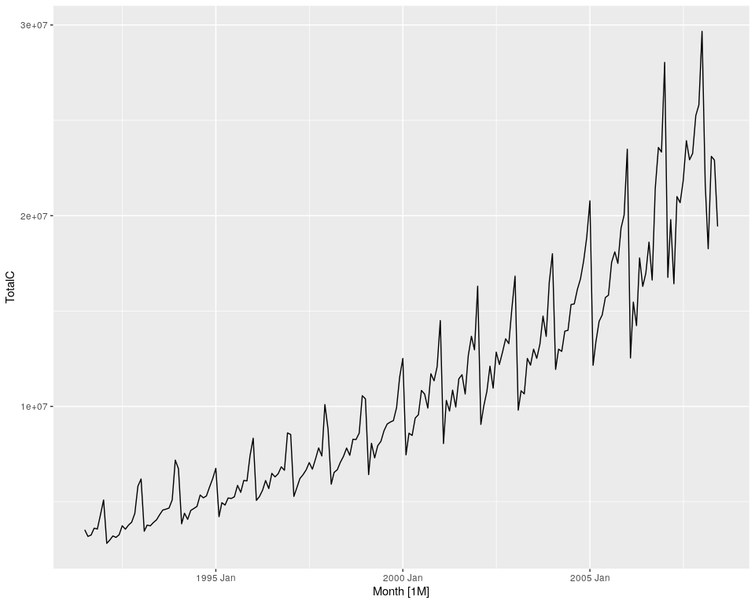

```r
autoplot(a10)
```

Puedo usar `gg_season` para examinar mejor el componente estacional de la serie:

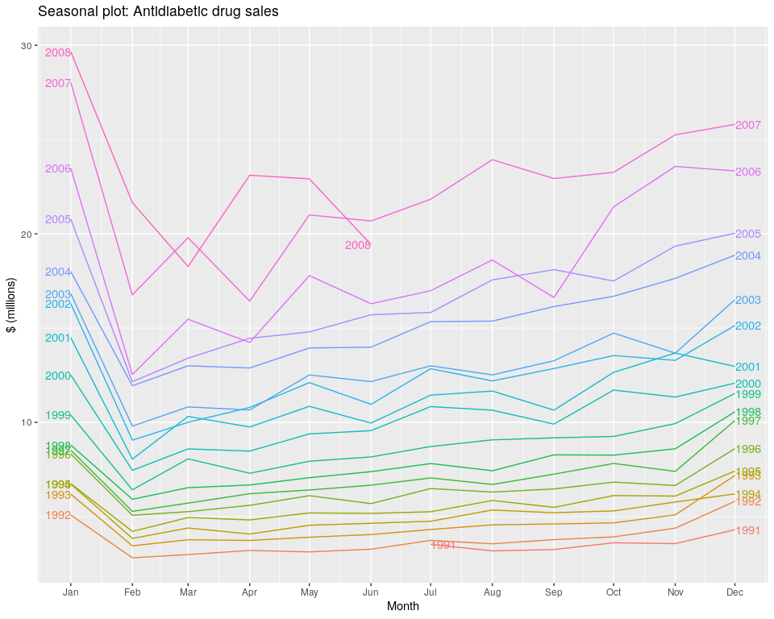

```r
a10 %>%
  gg_season(Cost, labels = "both") +
  labs(
    y = "$ (millions)",
    title = "Seasonal plot: Antidiabetic drug sales"
  )
```

### Multiples períodos

Supongamos que tenemos datos de consumo eléctrico cada 30 minutos:

```r
vic_elec %>% head()
```

```
## # A tsibble: 6 x 5 [30m] <Australia/Melbourne>
##   Time                Demand Temperature Date       Holiday
##   <dttm>               <dbl>       <dbl> <date>     <lgl>
## 1 2012-01-01 00:00:00  4383.        21.4 2012-01-01 TRUE
## 2 2012-01-01 00:30:00  4263.        21.0 2012-01-01 TRUE
## 3 2012-01-01 01:00:00  4049.        20.7 2012-01-01 TRUE
## 4 2012-01-01 01:30:00  3878.        20.6 2012-01-01 TRUE
## 5 2012-01-01 02:00:00  4036.        20.4 2012-01-01 TRUE
## 6 2012-01-01 02:30:00  3866.        20.2 2012-01-01 TRUE
```

Usando el parámetro `period` podemos especificar el periodo de tiempo que queremos examinar en busca de efectos estacionales:

```r
vic_elec %>% gg_season(Demand, period = "day") +
  theme(legend.position = "none") +
  labs(y = "MWh", title = "Electricity demand: Victoria")

vic_elec %>% gg_season(Demand, period = "week") +
  theme(legend.position = "none") +
  labs(y = "MWh", title = "Electricity demand: Victoria")

vic_elec %>% gg_season(Demand, period = "year") +
  labs(y = "MWh", title = "Electricity demand: Victoria")
```

[figure not shown]

[figure not shown]

[figure not shown]

### Seasonal subseries plots

Esta opción nos permite tener un gráfico separado para cada periodo de tiempo. Permite ver mejor los efectos que tiene cada estación, así como detectar si estos efectos hay ido variando con el tiempo.

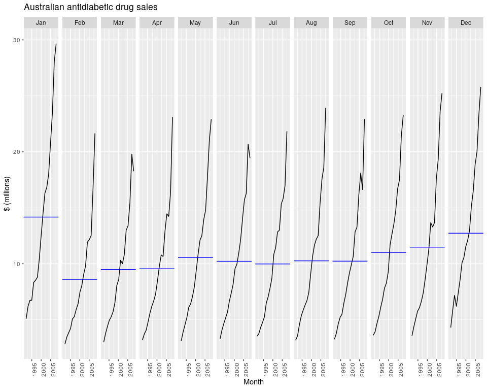

```r
a10 %>%
  gg_subseries(Cost) +
  labs(
    y = "$ (millions)",
    title = "Australian antidiabetic drug sales"
  )
```

## Scatterplots

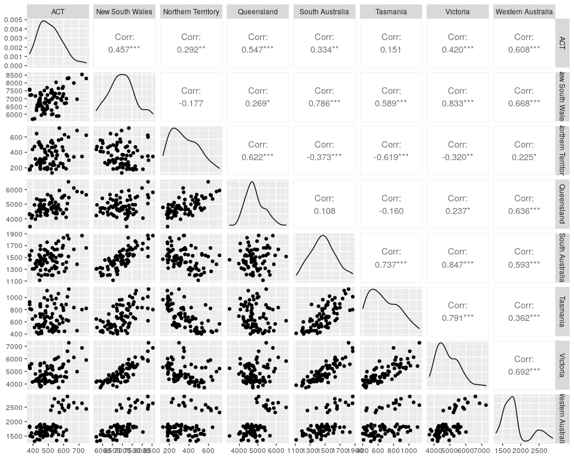

```r
visitors <- tourism %>%
  group_by(State) %>%
  summarise(Trips = sum(Trips))
visitors %>%
  pivot_wider(values_from = Trips, names_from = State) %>%
  GGally::ggpairs(columns = 2:9)
```

## Lag plots

`gg_lag` arma por sí sola un gráfico de la variable de interés contra distintos lags de la misma.

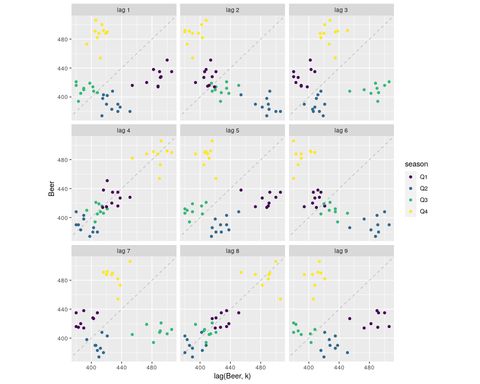

```r
recent_production <- aus_production %>%
  filter(year(Quarter) >= 2000)
recent_production %>%
  gg_lag(Beer, geom = "point") +
  labs(x = "lag(Beer, k)")
```

## Autocorrelation

Así como ploteamos los lags de una variable, podemos calcular la correlación entre la variable y sus lags. Esto se hace con la función `ACF`:

```r
recent_production %>% ACF(Beer, lag_max = 9)
```

```
## # A tsibble: 9 x 2 [1Q]
##     lag      acf
##   <lag>    <dbl>
## 1    1Q -0.0530
## 2    2Q -0.758
## 3    3Q -0.0262
## 4    4Q  0.802
## 5    5Q -0.0775
## 6    6Q -0.657
## 7    7Q  0.00119
## 8    8Q  0.707
## 9    9Q -0.0888
```

Y si lo ploteamos:

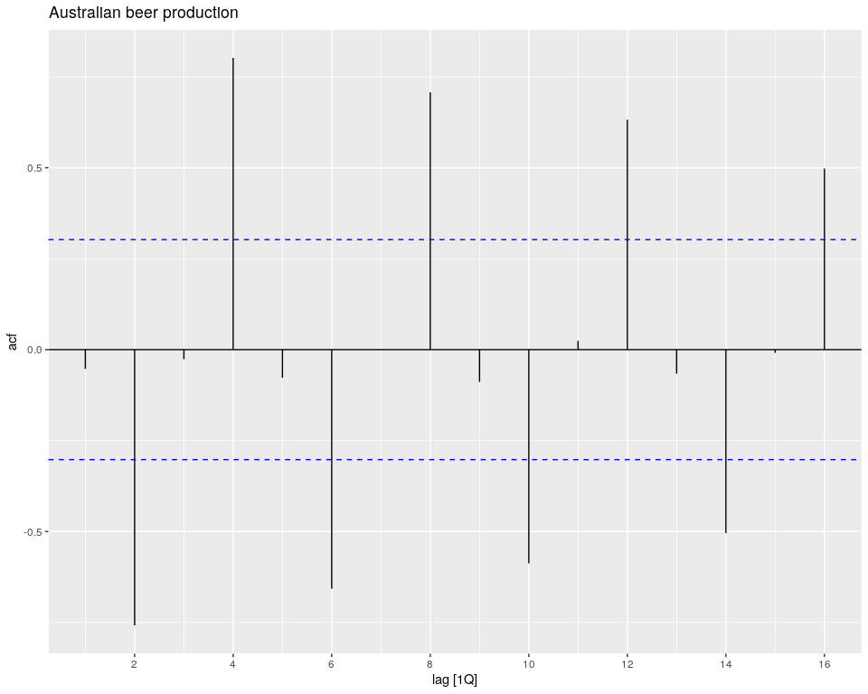

```r
recent_production %>%
  ACF(Beer) %>%
  autoplot() + labs(title = "Australian beer production")
```

Cuando no hay estacionalidad ni tendencia, se dice que la serie se comporta como un proceso de ruido blanco, y se ve así:

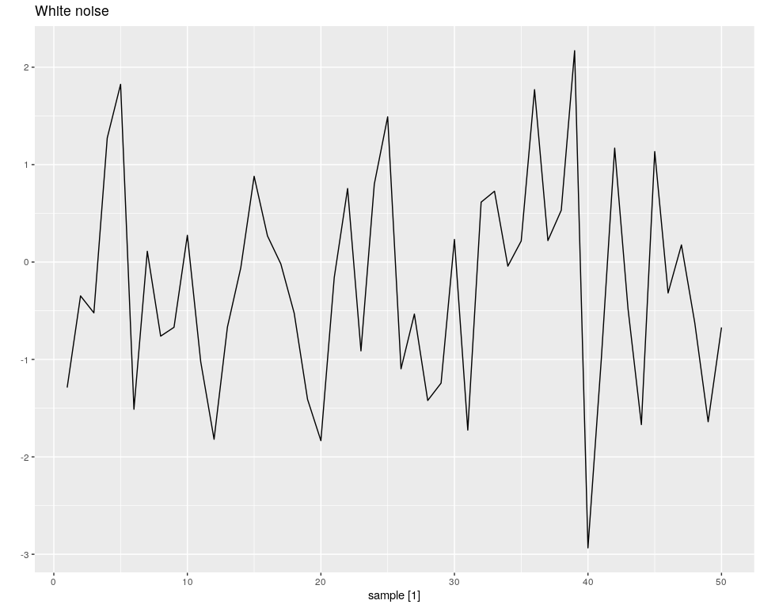

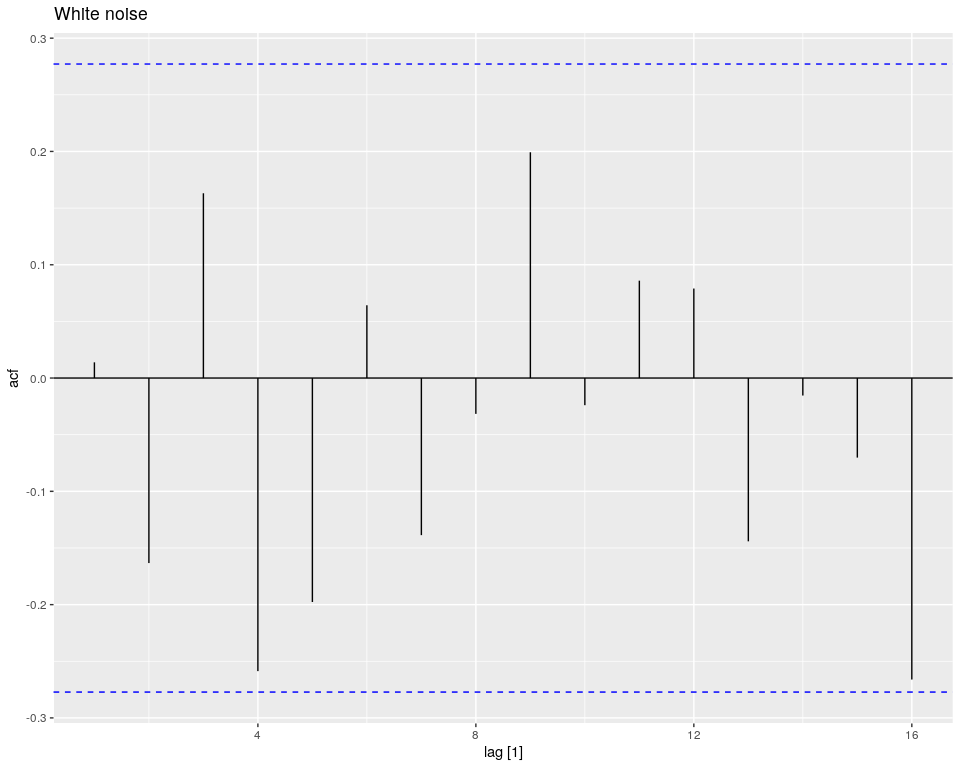

```r
set.seed(30)
y <- tsibble(sample = 1:50, wn = rnorm(50), index = sample)
y %>% autoplot(wn) + labs(title = "White noise", y = "")

y %>%
  ACF(wn) %>%
  autoplot() + labs(title = "White noise")
```